# SDG 4 in ASEAN: what the UIS data show, and where they are thin

**Data:** UIS public data API, release **20261110-392b682a**, downloaded 2026-11-24 15:19:52 WIB. 1,697 values for 11 ASEAN member states (including Timor-Leste), 2010–2026, 14 indicators. The code is at the repository root; `Rscript run.R --refresh` rebuilds everything from the live API.

## 1. Where the data are thin

Share of years since 2015 that have a value, by indicator and country. Completion rates come from household surveys, so they are much sparser than enrolment-based indicators, which come from the annual UIS survey. That gap matters most for SDG 4.1.2, the headline completion indicator.

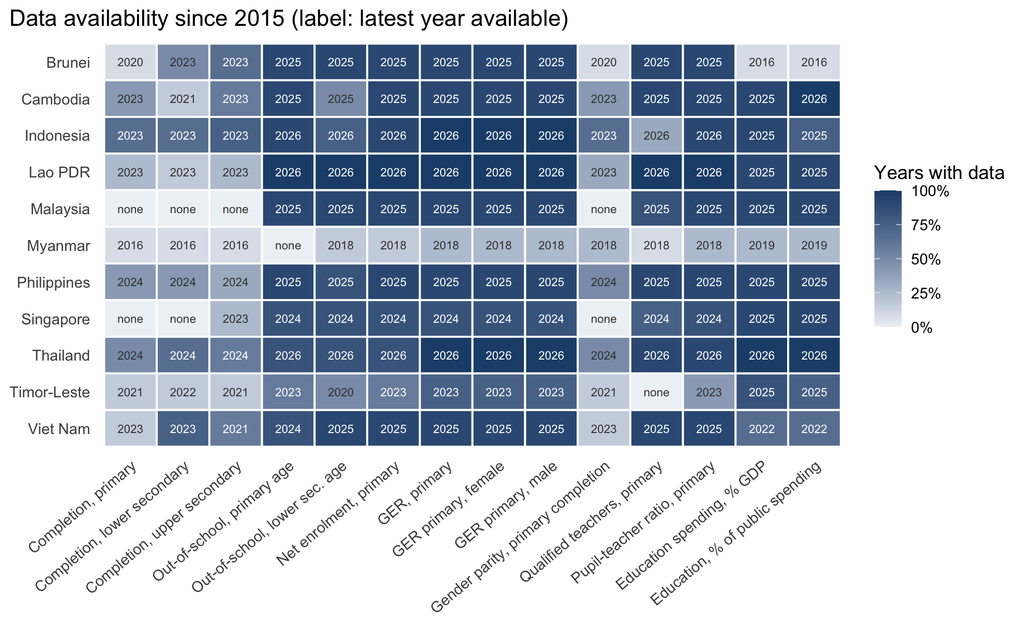

## 2. Completion rates (SDG 4.1.2)

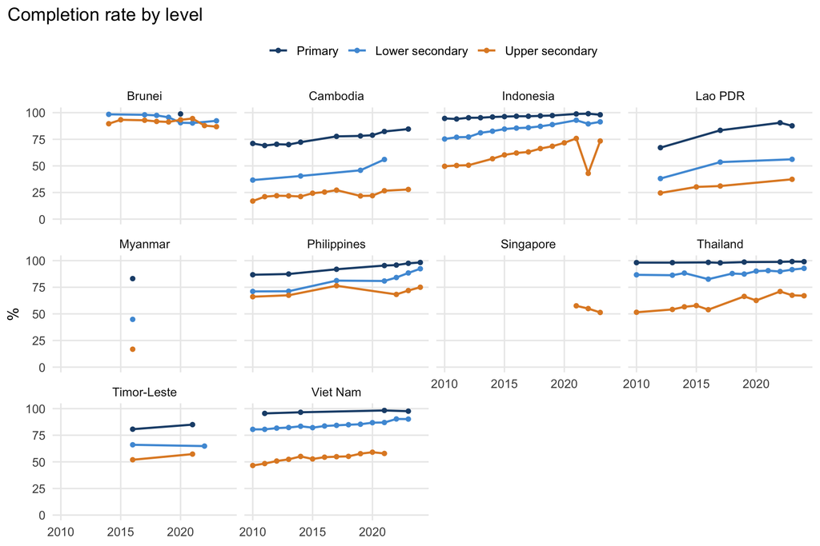

Completion falls with each level everywhere. The steepest drop between lower and upper secondary, in the latest available years, is in Viet Nam, Cambodia, Myanmar, Thailand (32, 28, 28, 26 points). Myanmar’s latest completion data are from 2016, and Singapore reports only upper-secondary completion. Viet Nam’s latest lower-secondary and upper-secondary figures come from different years, so its gap is approximate.

## 3. Out-of-school rates (SDG 4.1.4), latest year

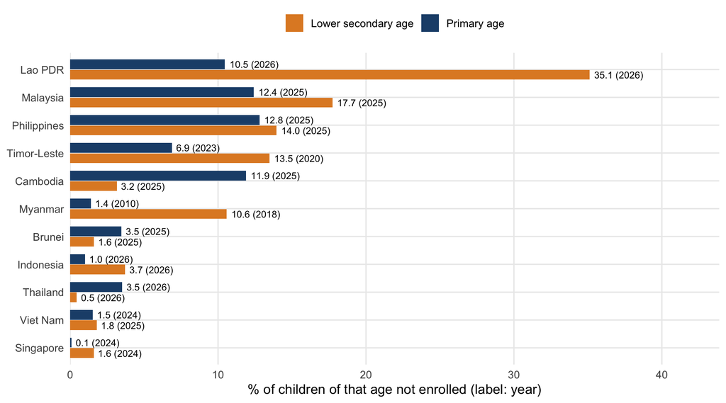

## 4. Public spending against the Education 2030 benchmarks

The Education 2030 Framework for Action asks countries to spend at least 4–6% of GDP, or at least 15–20% of total public expenditure, on education. The chart shows each country’s latest figures; the shaded corner meets neither benchmark.

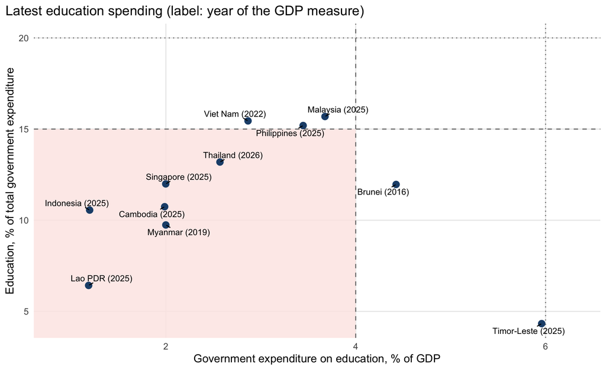

By the latest figures, 6 of 11 countries meet neither benchmark: Cambodia, Indonesia, Lao PDR, Myanmar, Singapore, Thailand. Indonesia’s figure (10.6% of government spending) sits well below the 20% of the budget the Indonesian constitution earmarks for education. The two measure different things: the national figure counts transfers and spending categories differently from the UIS definition. Anyone comparing the two needs to reconcile the definitions first.

## 5. Quality checks on the published series

Automated checks run on every download (code in `R/checks.R`):

- **Range:** bounded percentages (completion, net enrolment, out-of-school, qualified teachers) must lie in 0–100.
- **Identity:** the out-of-school rate must equal 100 minus the total net enrolment rate (tolerance 0.5 points).
- **Sex bracket:** the both-sexes GER must lie between the female and male values.
- **Jumps:** a change of more than 10 points between consecutive observations (gaps of up to two years).

| Check | Flags |
| --- | --- |
| range | 0 |
| oos_identity | 0 |
| sex_bracket | 0 |
| jump | 14 |

The range, identity and sex-bracket checks pass on every value: the published series are internally consistent. The jump check finds the series below. A jump is not an error. It can reflect a new data source, a revised population estimate or a real change. It is the question an analyst would put to the country, or check against the metadata, before using the number.

| Country | Indicator | Year | Change |
| --- | --- | --- | --- |
| Brunei | Qualified teachers, primary | 2021 | -17.6 points since 2020 (85.2 -> 67.6) |
| Brunei | Qualified teachers, primary | 2022 | +17.1 points since 2021 (67.6 -> 84.7) |
| Indonesia | Completion, upper secondary | 2022 | -32.8 points since 2021 (75.8 -> 43.0) |
| Indonesia | Completion, upper secondary | 2023 | +30.4 points since 2022 (43.0 -> 73.4) |
| Indonesia | Qualified teachers, primary | 2026 | +28.8 points since 2025 (34.7 -> 63.5) |
| Cambodia | Completion, lower secondary | 2021 | +10.2 points since 2019 (45.9 -> 56.0) |
| Cambodia | Out-of-school, lower sec. age | 2011 | +11.1 points since 2010 (14.8 -> 25.9) |
| Cambodia | Out-of-school, lower sec. age | 2025 | -14.4 points since 2024 (17.6 -> 3.2) |
| Lao PDR | Qualified teachers, primary | 2023 | -24.0 points since 2022 (89.7 -> 65.7) |
| Thailand | GER primary, male | 2011 | +10.4 points since 2010 (85.4 -> 95.8) |
| Timor-Leste | GER, primary | 2021 | +13.0 points since 2020 (110.6 -> 123.6) |
| Timor-Leste | GER primary, female | 2021 | +13.6 points since 2020 (109.9 -> 123.5) |
| Timor-Leste | GER primary, male | 2021 | +12.3 points since 2020 (111.3 -> 123.6) |
| Viet Nam | Qualified teachers, primary | 2021 | -15.4 points since 2020 (99.7 -> 84.3) |

Two patterns stand out:

- **Indonesia, upper-secondary completion:** 75.8% in 2021, 43.0% in 2022, 73.4% in 2023. A one-year collapse and recovery of that size looks more like a source or estimation issue in 2022 than a real change, and that year should not be used for trend statements without checking.
- **Qualified primary teachers (TRTP.1):** large breaks in Brunei, Indonesia, Lao PDR and Viet Nam. Changes to the national definition of the “minimum required qualification” are a common cause of breaks in this indicator, so trends should be read alongside the metadata.

## Method notes

- Indicator definitions follow the UIS glossary. Values are taken as published; nothing is re-estimated here.
- `NAT_EST` and `UIS_EST` qualifiers (national and UIS estimates) are kept in the data file.
- Timor-Leste is included as the eleventh ASEAN member.
- Reproduce: `Rscript run.R` (offline, from the saved snapshot) or `Rscript run.R --refresh` (live API). Tests: `Rscript -e 'testthat::test_dir("tests/testthat")'`.